# Unit - 1,2,3 Question Bank Solution

## 91 “To upload the ‘diabetes_unclean.csv’ to your working folder

First import the following libraries import pandas as pd import matplotlib.pyplot as plt import numpy as np

1. Make a data frame with the variable name df
2. To display the specific statistics or measures that are relevant for object-type columns
3. To display the specific statistics or measures that are relevant for numerical-type columns
4. How many rows and columns are in a given dataset
5. To check the missing values
6. To replace the missing values in the column ““HbA1c”” with their mean value
7. Dropping the missing values of other columns
8. Display the correlation between variables
9. Checking the outliers in the dataset for the following parameters: ‘AGE’, ‘Urea’, ‘HbA1c’, ‘Chol’, ‘TG’, ‘HDL’, ‘LDL’, ‘VLDL’, ‘BMI’ using box plot with labels and title
10. Visualized the ““Urea”“,”“HbA1c”“,”“TG”” and ““BMI”” parameters for different ages using parallel_coordinates with labels and title
11. Remove the rows whose gender column has an “f” value and give the frequency count of the “F” and “M” values in different CLASS values
12. Remove the outliers in the ““HbA1c”” columns and print the shape of the data frame Note: all task output with specific question numbers and follow the sequence Example: print(“Ans-1”)”

[output not shown]

[output cut: 34 more lines]

```
BMI        0.016989  0.110120  0.072581 -0.068723  0.198048  1.000000

Ans-11: Frequency count of 'F' and 'M' in different CLASS values after removing 'F' rows:
CLASS  Gender
N      M          38
N      M           1
P      M          36
Y      M         482
       f           1
Y      M           6
       f           1
dtype: int64

Ans-12: Shape of DataFrame after removing 'HbA1c' outliers:
(563, 14)
```

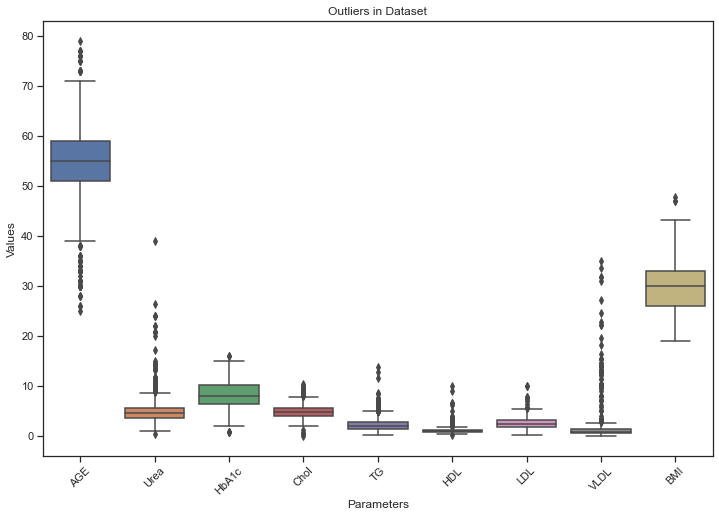

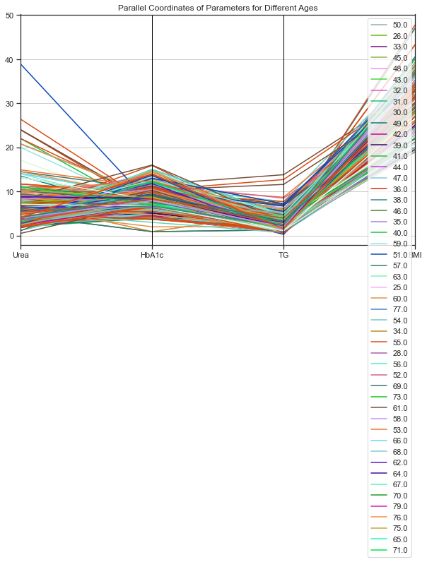

```python
import pandas as pd
import matplotlib.pyplot as plt
import seaborn as sns

# 1. Load the 'diabetes_unclean.csv' file into a DataFrame named df
df = pd.read_csv('https://raw.githubusercontent.com/patelmanishv/Sem4Data/main/Data/diabetes_unclean.csv')

# 2. Display specific statistics for object-type columns
print("Ans-2: Statistics for object-type columns:")
print(df.select_dtypes(include=['object']).describe())

# 3. Display specific statistics for numerical-type columns
print("\nAns-3: Statistics for numerical-type columns:")
print(df.select_dtypes(include=['int', 'float']).describe())

# 4. Number of rows and columns in the dataset
print("\nAns-4: Number of rows and columns in the dataset:")
print(f"Rows: {df.shape[0]}, Columns: {df.shape[1]}")

# 5. Check for missing values
print("\nAns-5: Checking for missing values:")
print(df.isnull().sum())

# 6. Replace missing values in 'HbA1c' column with mean value
mean_hba1c = df['HbA1c'].mean()
df['HbA1c'].fillna(mean_hba1c, inplace=True)

# 7. Drop missing values from other columns
df.dropna(inplace=True)

# 8. Display correlation between variables
print("\nAns-8: Correlation between variables:")
print(df.corr())

# 9. Check outliers using box plot
outliers_cols = ['AGE', 'Urea', 'HbA1c', 'Chol', 'TG', 'HDL', 'LDL', 'VLDL', 'BMI']
plt.figure(figsize=(12, 8))
sns.boxplot(data=df[outliers_cols])
plt.xticks(rotation=45)
plt.title('Outliers in Dataset')
plt.xlabel('Parameters')
plt.ylabel('Values')
plt.show()

# 10. Visualize 'Urea', 'HbA1c', 'TG', 'BMI' parameters for different ages using parallel_coordinates
plt.figure(figsize=(10, 6))
sns.set(style="ticks")
parallel_data = df[['AGE', 'Urea', 'HbA1c', 'TG', 'BMI']]
pd.plotting.parallel_coordinates(parallel_data, class_column='AGE')
plt.title('Parallel Coordinates of Parameters for Different Ages')
plt.show()

# 11. Remove rows with 'F' value in the 'gender' column and show frequency count of 'F' and 'M' in CLASS
df = df[df['Gender'] != 'F']  # Exclude rows where 'Gender' is 'F'
gender_class_count = df.groupby(['CLASS', 'Gender']).size()
print("\nAns-11: Frequency count of 'F' and 'M' in different CLASS values after removing 'F' rows:")
print(gender_class_count)

# 12. Remove outliers in 'HbA1c' column and print shape of DataFrame
q1 = df['HbA1c'].quantile(0.25)
q3 = df['HbA1c'].quantile(0.75)
iqr = q3 - q1
lower_bound = q1 - 1.5 * iqr
upper_bound = q3 + 1.5 * iqr
df = df[(df['HbA1c'] >= lower_bound) & (df['HbA1c'] <= upper_bound)]
print("\nAns-12: Shape of DataFrame after removing 'HbA1c' outliers:")
print(df.shape)
```

## UNIT - 3

```python
## 1. Print Phone Number from Given String:

import re

text = "My phone number is 123-456-7890"
phone_number = re.search(r'\d{3}-\d{3}-\d{4}', text)
if phone_number:
    print("Phone number found:", phone_number.group())
else:
    print("Phone number not found")
```

```
Phone number found: 123-456-7890
```

```python
## 2. Check String Contains Certain Set of Characters:

import re

text = "Hello123World"
if re.match(r'^[a-zA-Z0-9]+$', text):
    print("String contains only a-z, A-Z, and 0-9.")
else:
    print("String contains other characters.")
```

```
String contains only a-z, A-Z, and 0-9.
```

```python
## 3. Match 'a' followed by zero or more 'b's:

import re

text = "ab abb abbb"
matches = re.findall(r'ab*', text)
print(matches)
```

```
['ab', 'abb', 'abbb']
```

```python
## 4. Match 'a' followed by one or more 'b's:

import re

text = "ab abb abbb"
matches = re.findall(r'ab+', text)
print(matches)
```

```
['ab', 'abb', 'abbb']
```

```python
## 5. Match 'a' followed by zero or one 'b':

import re

text = "ab abb ac"
matches = re.findall(r'ab?', text)
print(matches)
```

```
['ab', 'ab', 'a']
```

```python
## 6. Match 'a' followed by three 'b's:

import re

text = "ab abbb ac abb"
matches = re.findall(r'ab{3}', text)
print(matches)
```

```
['abbb']
```

```python
## 7. Find Lowercase Letters Joined by an Underscore:

import re

text = "hello_world abc_def_123"
matches = re.findall(r'[a-z]+_[a-z]+', text)
print(matches)
```

```
['hello_world', 'abc_def']
```

```python
## 8. Find Upper Case Letter Followed by Lower Case Letters:

import re

text = "Apple orange Banana mango"
matches = re.findall(r'[A-Z][a-z]+', text)
print(matches)
```

```
['Apple', 'Banana']
```

```python
## 9. Match a Word at the End of a String with Optional Punctuation:

import re

text = "This is a test, okay?"
matches = re.findall(r'\b\w+\b[.,?!]*$', text)
print(matches)
```

```
['okay?']
```

```python
## 10. Match a Word Containing 'z':

import re

text = "This is a test for the zoo"
matches = re.findall(r'\b\w*z\w*\b', text)
print(matches)
```

```
['zoo']
```

```python
## 11. Match String with Upper and Lowercase Letters, Numbers, and Underscores:

import re

text = "Hello_World123_xyz"
if re.match(r'^[a-zA-Z0-9_]+$', text):
    print("String matches the pattern.")
else:
    print("String doesn't match the pattern.")
```

```
String matches the pattern.
```

```python
## 12. Start Each String with a Specific Number:

import re

text = "123abc 456def 789ghi"
modified_text = re.sub(r'\b', '42 ', text)
print(modified_text)
```

```
42 123abc42  42 456def42  42 789ghi42
```

```python
## 13. Remove Leading Zeros from an IP Address:

import re

ip_address = "192.168.001.001"
modified_ip = re.sub(r'\b0+(\d+)', r'\1', ip_address)
print(modified_ip)
```

```
192.168.1.1
```

```python
## 14. Check for a Number at the End of a String:

import re

text = "This is a sample123"
if re.search(r'\d$', text):
    print("Number found at the end of the string.")
else:
    print("No number found at the end.")
```

```
Number found at the end of the string.
```

```python
## 15. Search for Literal Strings within a String:

import re

text = "Hello, this is a test."
search_string = "test"
if re.search(re.escape(search_string), text):
    print("String found.")
else:
    print("String not found.")
```

```
String found.
```

```python
## 16. Extract Year, Month, and Date from a URL:

import re

url = "https://example.com/2024/05/10/page"
match = re.search(r'/(\d{4})/(\d{2})/(\d{2})/', url)
if match:
    year, month, day = match.groups()
    print("Year:", year)
    print("Month:", month)
    print("Day:", day)
else:
    print("Date not found in the URL.")
```

```
Year: 2024
Month: 05
Day: 10
```

```python
## 17. Convert yyyy-mm-dd Format to dd-mm-yyyy Format:

import re

date = "2024-05-10"
modified_date = re.sub(r'(\d{4})-(\d{2})-(\d{2})', r'\3-\2-\1', date)
print(modified_date)
```

```
10-05-2024
```

```python
## 18. Find Words Starting with 'a' or 'e' in a String:

import re

text = "apple banana elephant ant eagle"
matches = re.findall(r'\b[ae]\w+', text)
print(matches)
```

```
['apple', 'elephant', 'ant', 'eagle']
```

```python
## 19. Abbreviate 'Road' as 'Rd.' in a String:

import re

text = "This is a Road trip"
modified_text = re.sub(r'\bRoad\b', 'Rd.', text)
print(modified_text)
```

```
This is a Rd. trip
```

```python
## 20. Replace Spaces, Commas, or Dots with a Colon:

import re

text = "Hello, world. How are you?"
modified_text = re.sub(r'[ ,.]+', ':', text)
print(modified_text)
```

```
Hello:world:How:are:you?
```

```python
## 21. Replace Maximum 2 Occurrences of Space, Comma, or Dot with a Colon:

import re

text = "Hello, world. How are you?"
modified_text = re.sub(r'[ ,.]{1,2}', ':', text, count=2)
print(modified_text)
```

```
Hello:world:How are you?
```

```python
## 22. Convert CamelCase String to SnakeCase:

import re

camel_case = "CamelCaseExample"
snake_case = re.sub(r'(?<!^)(?=[A-Z])', '_', camel_case).lower()
print(snake_case)
```

```
camel_case_example
```

```python
## 23. Remove Multiple Spaces from a String and Store Output in List:

import re

text = "This   is   a    test  string"
words_list = re.split(r'\s+', text)
print(words_list)
```

```
['This', 'is', 'a', 'test', 'string']
```

```python
## 24. Split a String into Uppercase Letters:

import re

text = "HelloWorldPython"
upper_letters = re.findall(r'[A-Z]', text)
print(upper_letters)
```

```
['H', 'W', 'P']
```

```python
## 25. Remove Parenthesis Area in a String:

import re

text = "Hello (World)"
modified_text = re.sub(r'\(.*?\)', '', text)
print(modified_text)
```

```
Hello
```

```python
## 26. Insert Spaces Between Words Starting with Capital Letters:

import re

text = "HelloWorldPythonIsGreat"
modified_text = re.sub(r'([a-z])([A-Z])', r'\1 \2', text)
print(modified_text)
```

```
Hello World Python Is Great
```

```python
## 28. Remove Lowercase Substrings from a String:

import re

text = "ABcdEfGhI"
modified_text = re.sub(r'[a-z]', '', text)
print(modified_text)
```

```
ABEGI
```

```python
## 29. Check if a Word Starts and Ends with a Vowel in a String:

import re

def starts_ends_vowel(text):
    words = text.split()
    for word in words:
        if re.match(r'^[aeiouAEIOU].*[aeiouAEIOU]$', word):
            return True
    return False

sample_data = ["Red Orange White", "Red White Black", "abcd dkise eosksu"]
for data in sample_data:
    print(f'"{data}" -> {starts_ends_vowel(data)}')
```

```
"Red Orange White" -> True
"Red White Black" -> False
"abcd dkise eosksu" -> True
```

```python
## 30. Check for Consecutive Words Ending and Starting with a Vowel:

import re

def consecutive_vowels(text):
    words = text.split()
    for i in range(len(words) - 1):
        current_word = words[i]
        next_word = words[i + 1]
        if re.match(r'[aeiouAEIOU]$', current_word[-1]) and re.match(r'^[aeiouAEIOU]', next_word):
            return True
    return False

sample_data = [
    "These exercises can be used for practice.",
    "Following exercises should be removed for practice.",
    "I use these stories in my classroom."
]
for data in sample_data:
    print(f'"{data}" -> {consecutive_vowels(data)}')
```

```
"These exercises can be used for practice." -> True
"Following exercises should be removed for practice." -> False
"I use these stories in my classroom." -> True
```

```python
## 31. Find all five-character words in a string:

import re

text = 'The quick brown fox jumps over the lazy dog.'
five_char_words = re.findall(r'\b\w{5}\b', text)
print(five_char_words)
```

```
['quick', 'brown', 'jumps']
```

```python
## 32. Perform tasks using the regex module on the given text:

import re

text = "   hello welcome to the python exam my email is alice@google.com, world this is bob@meta.com appearing for python exam    "

# a) Remove leading and trailing spaces
trimmed_text = text.strip()

# b) Replace space between words with '$' symbol
replaced_text = re.sub(r'\s+', '$', trimmed_text)

# c) Extract username and host name in a list
email_pattern = r'\b([a-zA-Z0-9._%+-]+)@([a-zA-Z0-9.-]+)\.([a-zA-Z]{2,})\b'
matches = re.findall(email_pattern, trimmed_text)
usernames = [match[0] for match in matches]
hosts = [match[1] for match in matches]

print("Trimmed Text:", trimmed_text)
print("Replaced Text:", replaced_text)
print("Usernames:", usernames)
print("Hosts:", hosts)
```

```
Trimmed Text: hello welcome to the python exam my email is alice@google.com, world this is bob@meta.com appearing for python exam
Replaced Text: hello$welcome$to$the$python$exam$my$email$is$alice@google.com,$world$this$is$bob@meta.com$appearing$for$python$exam
Usernames: ['alice', 'bob']
Hosts: ['google', 'meta']
```

```python
## 33. Find all URLs from a given text:

import re

text = "Hello all Students must visit at my website https://www.pandasrockstar.com for more information. Also, check out http://www.google.com"
url_pattern = r'https?://(?:www\.)?([a-zA-Z0-9.-]+)\.(com|net|org|edu)'
urls = re.findall(url_pattern, text)
found_urls = [f'http://{url[0]}.{url[1]}' for url in urls]
print("Found URLs:", found_urls)
```

```
Found URLs: ['http://pandasrockstar.com', 'http://google.com']
```